# Risk Factor Analysis

## Outcome Variable

**Outcome Variable:** ever_wasted

## Predictor Variables

**Intervention Variable:** nchldlt5

**Adjustment Set:**

- arm
- W_mage
- meducyrs
- feducyrs
- hhwealth_quart
- hfoodsec
- W_mhtcm
- W_mwtkg
- W_mbmi
- W_nrooms
- W_parity
- impfloor
- impsan
- safeh20
- delta_W_mage
- delta_meducyrs
- delta_feducyrs
- delta_hhwealth_quart
- delta_hfoodsec
- delta_W_mhtcm
- delta_W_mwtkg
- delta_W_mbmi
- delta_W_nrooms
- delta_W_parity
- delta_impfloor
- delta_impsan
- delta_safeh20

## Stratifying Variables

The analysis was stratified on these variable(s):

- agecat
- studyid
- country

## Data Summary

| agecat | studyid | country | nchldlt5 | ever_wasted | n_cell | n |
| --- | --- | --- | --- | --- | --- | --- |
| 0-24 months | iLiNS-Zinc | BURKINA FASO | 1 | 0 | 838 | 3189 |
| 0-24 months | iLiNS-Zinc | BURKINA FASO | 1 | 1 | 235 | 3189 |
| 0-24 months | iLiNS-Zinc | BURKINA FASO | 2+ | 0 | 1624 | 3189 |
| 0-24 months | iLiNS-Zinc | BURKINA FASO | 2+ | 1 | 492 | 3189 |
| 0-24 months | IRC | INDIA | 1 | 0 | 25 | 410 |
| 0-24 months | IRC | INDIA | 1 | 1 | 64 | 410 |
| 0-24 months | IRC | INDIA | 2+ | 0 | 116 | 410 |
| 0-24 months | IRC | INDIA | 2+ | 1 | 205 | 410 |
| 0-24 months | JiVitA-3 | BANGLADESH | 1 | 0 | 12739 | 26929 |
| 0-24 months | JiVitA-3 | BANGLADESH | 1 | 1 | 4485 | 26929 |
| 0-24 months | JiVitA-3 | BANGLADESH | 2+ | 0 | 7242 | 26929 |
| 0-24 months | JiVitA-3 | BANGLADESH | 2+ | 1 | 2463 | 26929 |
| 0-24 months | LCNI-5 | MALAWI | 1 | 0 | 366 | 812 |
| 0-24 months | LCNI-5 | MALAWI | 1 | 1 | 25 | 812 |
| 0-24 months | LCNI-5 | MALAWI | 2+ | 0 | 380 | 812 |
| 0-24 months | LCNI-5 | MALAWI | 2+ | 1 | 41 | 812 |
| 0-24 months | NIH-Crypto | BANGLADESH | 1 | 0 | 369 | 758 |
| 0-24 months | NIH-Crypto | BANGLADESH | 1 | 1 | 172 | 758 |
| 0-24 months | NIH-Crypto | BANGLADESH | 2+ | 0 | 139 | 758 |
| 0-24 months | NIH-Crypto | BANGLADESH | 2+ | 1 | 78 | 758 |
| 0-24 months | PROVIDE | BANGLADESH | 1 | 0 | 327 | 700 |
| 0-24 months | PROVIDE | BANGLADESH | 1 | 1 | 185 | 700 |
| 0-24 months | PROVIDE | BANGLADESH | 2+ | 0 | 127 | 700 |
| 0-24 months | PROVIDE | BANGLADESH | 2+ | 1 | 61 | 700 |
| 0-24 months | TanzaniaChild2 | TANZANIA, UNITED REPUBLIC OF | 1 | 0 | 1242 | 2385 |
| 0-24 months | TanzaniaChild2 | TANZANIA, UNITED REPUBLIC OF | 1 | 1 | 395 | 2385 |
| 0-24 months | TanzaniaChild2 | TANZANIA, UNITED REPUBLIC OF | 2+ | 0 | 579 | 2385 |
| 0-24 months | TanzaniaChild2 | TANZANIA, UNITED REPUBLIC OF | 2+ | 1 | 169 | 2385 |
| 0-6 months | IRC | INDIA | 1 | 0 | 37 | 410 |
| 0-6 months | IRC | INDIA | 1 | 1 | 52 | 410 |
| 0-6 months | IRC | INDIA | 2+ | 0 | 150 | 410 |
| 0-6 months | IRC | INDIA | 2+ | 1 | 171 | 410 |
| 0-6 months | JiVitA-3 | BANGLADESH | 1 | 0 | 14046 | 26832 |
| 0-6 months | JiVitA-3 | BANGLADESH | 1 | 1 | 3099 | 26832 |
| 0-6 months | JiVitA-3 | BANGLADESH | 2+ | 0 | 8058 | 26832 |
| 0-6 months | JiVitA-3 | BANGLADESH | 2+ | 1 | 1629 | 26832 |
| 0-6 months | LCNI-5 | MALAWI | 1 | 0 | 121 | 267 |
| 0-6 months | LCNI-5 | MALAWI | 1 | 1 | 1 | 267 |
| 0-6 months | LCNI-5 | MALAWI | 2+ | 0 | 142 | 267 |
| 0-6 months | LCNI-5 | MALAWI | 2+ | 1 | 3 | 267 |
| 0-6 months | NIH-Crypto | BANGLADESH | 1 | 0 | 405 | 758 |
| 0-6 months | NIH-Crypto | BANGLADESH | 1 | 1 | 136 | 758 |
| 0-6 months | NIH-Crypto | BANGLADESH | 2+ | 0 | 158 | 758 |
| 0-6 months | NIH-Crypto | BANGLADESH | 2+ | 1 | 59 | 758 |
| 0-6 months | PROVIDE | BANGLADESH | 1 | 0 | 375 | 700 |
| 0-6 months | PROVIDE | BANGLADESH | 1 | 1 | 137 | 700 |
| 0-6 months | PROVIDE | BANGLADESH | 2+ | 0 | 144 | 700 |
| 0-6 months | PROVIDE | BANGLADESH | 2+ | 1 | 44 | 700 |
| 0-6 months | TanzaniaChild2 | TANZANIA, UNITED REPUBLIC OF | 1 | 0 | 1407 | 2385 |
| 0-6 months | TanzaniaChild2 | TANZANIA, UNITED REPUBLIC OF | 1 | 1 | 230 | 2385 |
| 0-6 months | TanzaniaChild2 | TANZANIA, UNITED REPUBLIC OF | 2+ | 0 | 646 | 2385 |
| 0-6 months | TanzaniaChild2 | TANZANIA, UNITED REPUBLIC OF | 2+ | 1 | 102 | 2385 |
| 6-24 months | iLiNS-Zinc | BURKINA FASO | 1 | 0 | 838 | 3189 |
| 6-24 months | iLiNS-Zinc | BURKINA FASO | 1 | 1 | 235 | 3189 |
| 6-24 months | iLiNS-Zinc | BURKINA FASO | 2+ | 0 | 1624 | 3189 |
| 6-24 months | iLiNS-Zinc | BURKINA FASO | 2+ | 1 | 492 | 3189 |
| 6-24 months | IRC | INDIA | 1 | 0 | 56 | 410 |
| 6-24 months | IRC | INDIA | 1 | 1 | 33 | 410 |
| 6-24 months | IRC | INDIA | 2+ | 0 | 227 | 410 |
| 6-24 months | IRC | INDIA | 2+ | 1 | 94 | 410 |
| 6-24 months | JiVitA-3 | BANGLADESH | 1 | 0 | 9417 | 17286 |
| 6-24 months | JiVitA-3 | BANGLADESH | 1 | 1 | 1787 | 17286 |
| 6-24 months | JiVitA-3 | BANGLADESH | 2+ | 0 | 5037 | 17286 |
| 6-24 months | JiVitA-3 | BANGLADESH | 2+ | 1 | 1045 | 17286 |
| 6-24 months | LCNI-5 | MALAWI | 1 | 0 | 360 | 800 |
| 6-24 months | LCNI-5 | MALAWI | 1 | 1 | 24 | 800 |
| 6-24 months | LCNI-5 | MALAWI | 2+ | 0 | 377 | 800 |
| 6-24 months | LCNI-5 | MALAWI | 2+ | 1 | 39 | 800 |
| 6-24 months | NIH-Crypto | BANGLADESH | 1 | 0 | 460 | 730 |
| 6-24 months | NIH-Crypto | BANGLADESH | 1 | 1 | 60 | 730 |
| 6-24 months | NIH-Crypto | BANGLADESH | 2+ | 0 | 174 | 730 |
| 6-24 months | NIH-Crypto | BANGLADESH | 2+ | 1 | 36 | 730 |
| 6-24 months | PROVIDE | BANGLADESH | 1 | 0 | 380 | 615 |
| 6-24 months | PROVIDE | BANGLADESH | 1 | 1 | 68 | 615 |
| 6-24 months | PROVIDE | BANGLADESH | 2+ | 0 | 136 | 615 |
| 6-24 months | PROVIDE | BANGLADESH | 2+ | 1 | 31 | 615 |
| 6-24 months | TanzaniaChild2 | TANZANIA, UNITED REPUBLIC OF | 1 | 0 | 1154 | 2010 |
| 6-24 months | TanzaniaChild2 | TANZANIA, UNITED REPUBLIC OF | 1 | 1 | 229 | 2010 |
| 6-24 months | TanzaniaChild2 | TANZANIA, UNITED REPUBLIC OF | 2+ | 0 | 533 | 2010 |
| 6-24 months | TanzaniaChild2 | TANZANIA, UNITED REPUBLIC OF | 2+ | 1 | 94 | 2010 |

The following strata were considered:

- agecat: 0-24 months, studyid: iLiNS-Zinc, country: BURKINA FASO
- agecat: 0-24 months, studyid: IRC, country: INDIA
- agecat: 0-24 months, studyid: JiVitA-3, country: BANGLADESH
- agecat: 0-24 months, studyid: LCNI-5, country: MALAWI
- agecat: 0-24 months, studyid: NIH-Crypto, country: BANGLADESH
- agecat: 0-24 months, studyid: PROVIDE, country: BANGLADESH
- agecat: 0-24 months, studyid: TanzaniaChild2, country: TANZANIA, UNITED REPUBLIC OF
- agecat: 0-6 months, studyid: IRC, country: INDIA
- agecat: 0-6 months, studyid: JiVitA-3, country: BANGLADESH
- agecat: 0-6 months, studyid: LCNI-5, country: MALAWI
- agecat: 0-6 months, studyid: NIH-Crypto, country: BANGLADESH
- agecat: 0-6 months, studyid: PROVIDE, country: BANGLADESH
- agecat: 0-6 months, studyid: TanzaniaChild2, country: TANZANIA, UNITED REPUBLIC OF
- agecat: 6-24 months, studyid: iLiNS-Zinc, country: BURKINA FASO
- agecat: 6-24 months, studyid: IRC, country: INDIA
- agecat: 6-24 months, studyid: JiVitA-3, country: BANGLADESH
- agecat: 6-24 months, studyid: LCNI-5, country: MALAWI
- agecat: 6-24 months, studyid: NIH-Crypto, country: BANGLADESH
- agecat: 6-24 months, studyid: PROVIDE, country: BANGLADESH
- agecat: 6-24 months, studyid: TanzaniaChild2, country: TANZANIA, UNITED REPUBLIC OF

### Dropped Strata

Some strata were dropped due to rare outcomes:

- agecat: 0-6 months, studyid: LCNI-5, country: MALAWI

## Methods Detail

We're interested in the causal parameters $E[Y_a]$ for all values of $a \in \mathcal{A}$. These parameters represent the mean outcome if, possibly contrary to fact, we intervened to set all units to have $A=a$. Under the randomization and positivity assumptions, these are identified by the statistical parameters $\psi_a=E_W[E_{Y|A,W}(Y|A=a,W)]$. In addition, we're interested in the mean of $Y$, $E[Y]$ under no intervention (the observed mean). We will estimate these parameters by using SuperLearner to fit the relevant likelihood factors -- $E_{Y|A,W}(Y|A=a,W)$ and $p(A=a|W)$, and then updating our likelihood fit using a joint TMLE.

For unadjusted analyses ($W=\{\}$), initial likelihoods were estimated using Lrnr_glm to estimate the simple $E(Y|A)$ and Lrnr_mean to estimate $p(A)$. For adjusted analyses, a small library containing Lrnr_glmnet, Lrnr_xgboost, and Lrnr_mean was used.

Having estimated these parameters, we will then use the delta method to estimate relative risks and attributable risks relative to a prespecified baseline level of $A$.

# Results Detail

## Results Plots

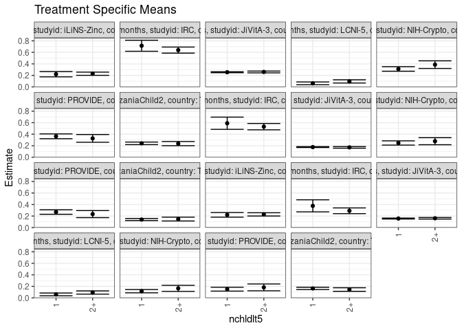

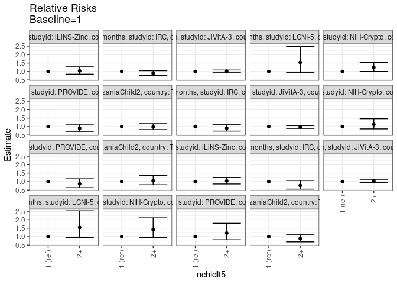

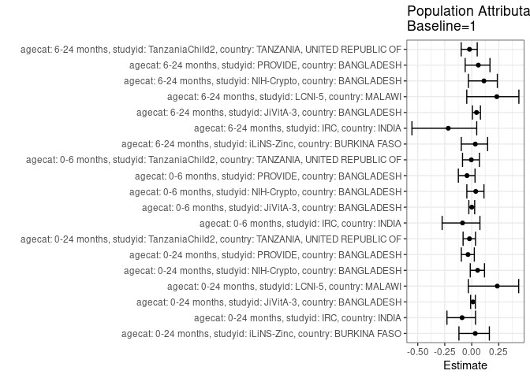

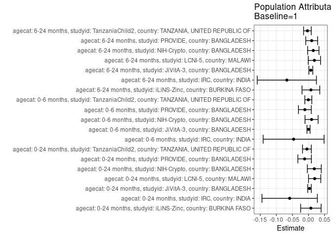

## Results Table

### Parameter: TSM

| agecat | studyid | country | intervention_level | baseline_level | estimate | ci_lower | ci_upper |
| --- | --- | --- | --- | --- | --- | --- | --- |
| 0-24 months | iLiNS-Zinc | BURKINA FASO | 1 | NA | 0.2205373 | 0.1750092 | 0.2660655 |
| 0-24 months | iLiNS-Zinc | BURKINA FASO | 2+ | NA | 0.2289949 | 0.2010962 | 0.2568936 |
| 0-24 months | IRC | INDIA | 1 | NA | 0.7146467 | 0.6190021 | 0.8102913 |
| 0-24 months | IRC | INDIA | 2+ | NA | 0.6396469 | 0.5869230 | 0.6923708 |
| 0-24 months | JiVitA-3 | BANGLADESH | 1 | NA | 0.2550002 | 0.2465944 | 0.2634061 |
| 0-24 months | JiVitA-3 | BANGLADESH | 2+ | NA | 0.2598841 | 0.2444723 | 0.2752959 |
| 0-24 months | LCNI-5 | MALAWI | 1 | NA | 0.0620647 | 0.0383410 | 0.0857884 |
| 0-24 months | LCNI-5 | MALAWI | 2+ | NA | 0.0954956 | 0.0673842 | 0.1236071 |
| 0-24 months | NIH-Crypto | BANGLADESH | 1 | NA | 0.3117904 | 0.2723522 | 0.3512287 |
| 0-24 months | NIH-Crypto | BANGLADESH | 2+ | NA | 0.3869819 | 0.3207131 | 0.4532508 |
| 0-24 months | PROVIDE | BANGLADESH | 1 | NA | 0.3635255 | 0.3217940 | 0.4052570 |
| 0-24 months | PROVIDE | BANGLADESH | 2+ | NA | 0.3273594 | 0.2602091 | 0.3945096 |
| 0-24 months | TanzaniaChild2 | TANZANIA, UNITED REPUBLIC OF | 1 | NA | 0.2414289 | 0.2191683 | 0.2636895 |
| 0-24 months | TanzaniaChild2 | TANZANIA, UNITED REPUBLIC OF | 2+ | NA | 0.2367788 | 0.2005110 | 0.2730466 |
| 0-6 months | IRC | INDIA | 1 | NA | 0.5901837 | 0.4841050 | 0.6962623 |
| 0-6 months | IRC | INDIA | 2+ | NA | 0.5310881 | 0.4762454 | 0.5859308 |
| 0-6 months | JiVitA-3 | BANGLADESH | 1 | NA | 0.1761130 | 0.1686727 | 0.1835532 |
| 0-6 months | JiVitA-3 | BANGLADESH | 2+ | NA | 0.1709766 | 0.1571195 | 0.1848337 |
| 0-6 months | NIH-Crypto | BANGLADESH | 1 | NA | 0.2476852 | 0.2108889 | 0.2844815 |
| 0-6 months | NIH-Crypto | BANGLADESH | 2+ | NA | 0.2782259 | 0.2169694 | 0.3394824 |
| 0-6 months | PROVIDE | BANGLADESH | 1 | NA | 0.2699159 | 0.2308840 | 0.3089478 |
| 0-6 months | PROVIDE | BANGLADESH | 2+ | NA | 0.2339445 | 0.1727484 | 0.2951406 |
| 0-6 months | TanzaniaChild2 | TANZANIA, UNITED REPUBLIC OF | 1 | NA | 0.1397553 | 0.1219409 | 0.1575696 |
| 0-6 months | TanzaniaChild2 | TANZANIA, UNITED REPUBLIC OF | 2+ | NA | 0.1474419 | 0.1142979 | 0.1805859 |
| 6-24 months | iLiNS-Zinc | BURKINA FASO | 1 | NA | 0.2204742 | 0.1804556 | 0.2604929 |
| 6-24 months | iLiNS-Zinc | BURKINA FASO | 2+ | NA | 0.2290044 | 0.2006644 | 0.2573444 |
| 6-24 months | IRC | INDIA | 1 | NA | 0.3770768 | 0.2723852 | 0.4817684 |
| 6-24 months | IRC | INDIA | 2+ | NA | 0.2913061 | 0.2413843 | 0.3412279 |
| 6-24 months | JiVitA-3 | BANGLADESH | 1 | NA | 0.1565750 | 0.1482951 | 0.1648549 |
| 6-24 months | JiVitA-3 | BANGLADESH | 2+ | NA | 0.1612547 | 0.1477157 | 0.1747936 |
| 6-24 months | LCNI-5 | MALAWI | 1 | NA | 0.0604525 | 0.0366890 | 0.0842161 |
| 6-24 months | LCNI-5 | MALAWI | 2+ | NA | 0.0933205 | 0.0652329 | 0.1214081 |
| 6-24 months | NIH-Crypto | BANGLADESH | 1 | NA | 0.1166308 | 0.0882739 | 0.1449878 |
| 6-24 months | NIH-Crypto | BANGLADESH | 2+ | NA | 0.1655552 | 0.1131152 | 0.2179952 |
| 6-24 months | PROVIDE | BANGLADESH | 1 | NA | 0.1511400 | 0.1178590 | 0.1844209 |
| 6-24 months | PROVIDE | BANGLADESH | 2+ | NA | 0.1828093 | 0.1235396 | 0.2420790 |
| 6-24 months | TanzaniaChild2 | TANZANIA, UNITED REPUBLIC OF | 1 | NA | 0.1640222 | 0.1437583 | 0.1842860 |
| 6-24 months | TanzaniaChild2 | TANZANIA, UNITED REPUBLIC OF | 2+ | NA | 0.1451984 | 0.1140939 | 0.1763029 |

### Parameter: E(Y)

| agecat | studyid | country | intervention_level | baseline_level | estimate | ci_lower | ci_upper |
| --- | --- | --- | --- | --- | --- | --- | --- |
| 0-24 months | iLiNS-Zinc | BURKINA FASO | NA | NA | 0.2279712 | 0.2010014 | 0.2549409 |
| 0-24 months | IRC | INDIA | NA | NA | 0.6560976 | 0.6100625 | 0.7021326 |
| 0-24 months | JiVitA-3 | BANGLADESH | NA | NA | 0.2580118 | 0.2515422 | 0.2644814 |
| 0-24 months | LCNI-5 | MALAWI | NA | NA | 0.0812808 | 0.0624736 | 0.1000879 |
| 0-24 months | NIH-Crypto | BANGLADESH | NA | NA | 0.3298153 | 0.2963239 | 0.3633067 |
| 0-24 months | PROVIDE | BANGLADESH | NA | NA | 0.3514286 | 0.3160364 | 0.3868207 |
| 0-24 months | TanzaniaChild2 | TANZANIA, UNITED REPUBLIC OF | NA | NA | 0.2364780 | 0.2194210 | 0.2535349 |
| 0-6 months | IRC | INDIA | NA | NA | 0.5439024 | 0.4956326 | 0.5921723 |
| 0-6 months | JiVitA-3 | BANGLADESH | NA | NA | 0.1762075 | 0.1705779 | 0.1818372 |
| 0-6 months | NIH-Crypto | BANGLADESH | NA | NA | 0.2572559 | 0.2261171 | 0.2883948 |
| 0-6 months | PROVIDE | BANGLADESH | NA | NA | 0.2585714 | 0.2261125 | 0.2910304 |
| 0-6 months | TanzaniaChild2 | TANZANIA, UNITED REPUBLIC OF | NA | NA | 0.1392034 | 0.1253080 | 0.1530987 |
| 6-24 months | iLiNS-Zinc | BURKINA FASO | NA | NA | 0.2279712 | 0.2010014 | 0.2549409 |
| 6-24 months | IRC | INDIA | NA | NA | 0.3097561 | 0.2649438 | 0.3545684 |
| 6-24 months | JiVitA-3 | BANGLADESH | NA | NA | 0.1638320 | 0.1577093 | 0.1699547 |
| 6-24 months | LCNI-5 | MALAWI | NA | NA | 0.0787500 | 0.0600738 | 0.0974262 |
| 6-24 months | NIH-Crypto | BANGLADESH | NA | NA | 0.1315068 | 0.1069744 | 0.1560393 |
| 6-24 months | PROVIDE | BANGLADESH | NA | NA | 0.1609756 | 0.1319065 | 0.1900447 |
| 6-24 months | TanzaniaChild2 | TANZANIA, UNITED REPUBLIC OF | NA | NA | 0.1606965 | 0.1446374 | 0.1767556 |

### Parameter: RR

| agecat | studyid | country | intervention_level | baseline_level | estimate | ci_lower | ci_upper |
| --- | --- | --- | --- | --- | --- | --- | --- |
| 0-24 months | iLiNS-Zinc | BURKINA FASO | 1 | 1 | 1.0000000 | 1.0000000 | 1.000000 |
| 0-24 months | iLiNS-Zinc | BURKINA FASO | 2+ | 1 | 1.0383499 | 0.8434195 | 1.278333 |
| 0-24 months | IRC | INDIA | 1 | 1 | 1.0000000 | 1.0000000 | 1.000000 |
| 0-24 months | IRC | INDIA | 2+ | 1 | 0.8950533 | 0.7647018 | 1.047625 |
| 0-24 months | JiVitA-3 | BANGLADESH | 1 | 1 | 1.0000000 | 1.0000000 | 1.000000 |
| 0-24 months | JiVitA-3 | BANGLADESH | 2+ | 1 | 1.0191523 | 0.9557492 | 1.086762 |
| 0-24 months | LCNI-5 | MALAWI | 1 | 1 | 1.0000000 | 1.0000000 | 1.000000 |
| 0-24 months | LCNI-5 | MALAWI | 2+ | 1 | 1.5386474 | 0.9515511 | 2.487976 |
| 0-24 months | NIH-Crypto | BANGLADESH | 1 | 1 | 1.0000000 | 1.0000000 | 1.000000 |
| 0-24 months | NIH-Crypto | BANGLADESH | 2+ | 1 | 1.2411604 | 1.0046465 | 1.533354 |
| 0-24 months | PROVIDE | BANGLADESH | 1 | 1 | 1.0000000 | 1.0000000 | 1.000000 |
| 0-24 months | PROVIDE | BANGLADESH | 2+ | 1 | 0.9005129 | 0.7133449 | 1.136790 |
| 0-24 months | TanzaniaChild2 | TANZANIA, UNITED REPUBLIC OF | 1 | 1 | 1.0000000 | 1.0000000 | 1.000000 |
| 0-24 months | TanzaniaChild2 | TANZANIA, UNITED REPUBLIC OF | 2+ | 1 | 0.9807392 | 0.8202934 | 1.172567 |
| 0-6 months | IRC | INDIA | 1 | 1 | 1.0000000 | 1.0000000 | 1.000000 |
| 0-6 months | IRC | INDIA | 2+ | 1 | 0.8998693 | 0.7313203 | 1.107264 |
| 0-6 months | JiVitA-3 | BANGLADESH | 1 | 1 | 1.0000000 | 1.0000000 | 1.000000 |
| 0-6 months | JiVitA-3 | BANGLADESH | 2+ | 1 | 0.9708347 | 0.8892313 | 1.059927 |
| 0-6 months | NIH-Crypto | BANGLADESH | 1 | 1 | 1.0000000 | 1.0000000 | 1.000000 |
| 0-6 months | NIH-Crypto | BANGLADESH | 2+ | 1 | 1.1233043 | 0.8618464 | 1.464080 |
| 0-6 months | PROVIDE | BANGLADESH | 1 | 1 | 1.0000000 | 1.0000000 | 1.000000 |
| 0-6 months | PROVIDE | BANGLADESH | 2+ | 1 | 0.8667311 | 0.6426751 | 1.168900 |
| 0-6 months | TanzaniaChild2 | TANZANIA, UNITED REPUBLIC OF | 1 | 1 | 1.0000000 | 1.0000000 | 1.000000 |
| 0-6 months | TanzaniaChild2 | TANZANIA, UNITED REPUBLIC OF | 2+ | 1 | 1.0550003 | 0.8148164 | 1.365983 |
| 6-24 months | iLiNS-Zinc | BURKINA FASO | 1 | 1 | 1.0000000 | 1.0000000 | 1.000000 |
| 6-24 months | iLiNS-Zinc | BURKINA FASO | 2+ | 1 | 1.0386900 | 0.8622635 | 1.251215 |
| 6-24 months | IRC | INDIA | 1 | 1 | 1.0000000 | 1.0000000 | 1.000000 |
| 6-24 months | IRC | INDIA | 2+ | 1 | 0.7725379 | 0.5573919 | 1.070728 |
| 6-24 months | JiVitA-3 | BANGLADESH | 1 | 1 | 1.0000000 | 1.0000000 | 1.000000 |
| 6-24 months | JiVitA-3 | BANGLADESH | 2+ | 1 | 1.0298874 | 0.9349337 | 1.134485 |
| 6-24 months | LCNI-5 | MALAWI | 1 | 1 | 1.0000000 | 1.0000000 | 1.000000 |
| 6-24 months | LCNI-5 | MALAWI | 2+ | 1 | 1.5436987 | 0.9423942 | 2.528672 |
| 6-24 months | NIH-Crypto | BANGLADESH | 1 | 1 | 1.0000000 | 1.0000000 | 1.000000 |
| 6-24 months | NIH-Crypto | BANGLADESH | 2+ | 1 | 1.4194807 | 0.9528851 | 2.114552 |
| 6-24 months | PROVIDE | BANGLADESH | 1 | 1 | 1.0000000 | 1.0000000 | 1.000000 |
| 6-24 months | PROVIDE | BANGLADESH | 2+ | 1 | 1.2095366 | 0.8172661 | 1.790088 |
| 6-24 months | TanzaniaChild2 | TANZANIA, UNITED REPUBLIC OF | 1 | 1 | 1.0000000 | 1.0000000 | 1.000000 |
| 6-24 months | TanzaniaChild2 | TANZANIA, UNITED REPUBLIC OF | 2+ | 1 | 0.8852368 | 0.6916600 | 1.132990 |

### Parameter: PAR

| agecat | studyid | country | intervention_level | baseline_level | estimate | ci_lower | ci_upper |
| --- | --- | --- | --- | --- | --- | --- | --- |
| 0-24 months | iLiNS-Zinc | BURKINA FASO | 1 | NA | 0.0074338 | -0.0243855 | 0.0392532 |
| 0-24 months | IRC | INDIA | 1 | NA | -0.0585491 | -0.1448037 | 0.0277055 |
| 0-24 months | JiVitA-3 | BANGLADESH | 1 | NA | 0.0030116 | -0.0026167 | 0.0086399 |
| 0-24 months | LCNI-5 | MALAWI | 1 | NA | 0.0192161 | 0.0000918 | 0.0383404 |
| 0-24 months | NIH-Crypto | BANGLADESH | 1 | NA | 0.0180249 | -0.0036713 | 0.0397210 |
| 0-24 months | PROVIDE | BANGLADESH | 1 | NA | -0.0120969 | -0.0332266 | 0.0090328 |
| 0-24 months | TanzaniaChild2 | TANZANIA, UNITED REPUBLIC OF | 1 | NA | -0.0049509 | -0.0185463 | 0.0086445 |
| 0-6 months | IRC | INDIA | 1 | NA | -0.0462812 | -0.1409521 | 0.0483896 |
| 0-6 months | JiVitA-3 | BANGLADESH | 1 | NA | 0.0000946 | -0.0046678 | 0.0048569 |
| 0-6 months | NIH-Crypto | BANGLADESH | 1 | NA | 0.0095707 | -0.0107831 | 0.0299245 |
| 0-6 months | PROVIDE | BANGLADESH | 1 | NA | -0.0113445 | -0.0313187 | 0.0086298 |
| 0-6 months | TanzaniaChild2 | TANZANIA, UNITED REPUBLIC OF | 1 | NA | -0.0005519 | -0.0114246 | 0.0103207 |
| 6-24 months | iLiNS-Zinc | BURKINA FASO | 1 | NA | 0.0074969 | -0.0201333 | 0.0351271 |
| 6-24 months | IRC | INDIA | 1 | NA | -0.0673207 | -0.1593463 | 0.0247049 |
| 6-24 months | JiVitA-3 | BANGLADESH | 1 | NA | 0.0072570 | 0.0011767 | 0.0133373 |
| 6-24 months | LCNI-5 | MALAWI | 1 | NA | 0.0182975 | -0.0008301 | 0.0374251 |
| 6-24 months | NIH-Crypto | BANGLADESH | 1 | NA | 0.0148760 | -0.0028186 | 0.0325706 |
| 6-24 months | PROVIDE | BANGLADESH | 1 | NA | 0.0098357 | -0.0086395 | 0.0283108 |
| 6-24 months | TanzaniaChild2 | TANZANIA, UNITED REPUBLIC OF | 1 | NA | -0.0033256 | -0.0152605 | 0.0086092 |

### Parameter: PAF

| agecat | studyid | country | intervention_level | baseline_level | estimate | ci_lower | ci_upper |
| --- | --- | --- | --- | --- | --- | --- | --- |
| 0-24 months | iLiNS-Zinc | BURKINA FASO | 1 | NA | 0.0326087 | -0.1184629 | 0.1632748 |
| 0-24 months | IRC | INDIA | 1 | NA | -0.0892384 | -0.2295005 | 0.0350224 |
| 0-24 months | JiVitA-3 | BANGLADESH | 1 | NA | 0.0116722 | -0.0103747 | 0.0332380 |
| 0-24 months | LCNI-5 | MALAWI | 1 | NA | 0.2364165 | -0.0315296 | 0.4347620 |
| 0-24 months | NIH-Crypto | BANGLADESH | 1 | NA | 0.0546514 | -0.0135734 | 0.1182839 |
| 0-24 months | PROVIDE | BANGLADESH | 1 | NA | -0.0344221 | -0.0963305 | 0.0239905 |
| 0-24 months | TanzaniaChild2 | TANZANIA, UNITED REPUBLIC OF | 1 | NA | -0.0209360 | -0.0800296 | 0.0349243 |
| 0-6 months | IRC | INDIA | 1 | NA | -0.0850910 | -0.2741181 | 0.0758921 |
| 0-6 months | JiVitA-3 | BANGLADESH | 1 | NA | 0.0005366 | -0.0268595 | 0.0272018 |
| 0-6 months | NIH-Crypto | BANGLADESH | 1 | NA | 0.0372030 | -0.0452813 | 0.1131784 |
| 0-6 months | PROVIDE | BANGLADESH | 1 | NA | -0.0438736 | -0.1239391 | 0.0304882 |
| 0-6 months | TanzaniaChild2 | TANZANIA, UNITED REPUBLIC OF | 1 | NA | -0.0039649 | -0.0851823 | 0.0711740 |
| 6-24 months | iLiNS-Zinc | BURKINA FASO | 1 | NA | 0.0328854 | -0.0966349 | 0.1471084 |
| 6-24 months | IRC | INDIA | 1 | NA | -0.2173345 | -0.5535867 | 0.0461405 |
| 6-24 months | JiVitA-3 | BANGLADESH | 1 | NA | 0.0442951 | 0.0065502 | 0.0806059 |
| 6-24 months | LCNI-5 | MALAWI | 1 | NA | 0.2323488 | -0.0460127 | 0.4366336 |
| 6-24 months | NIH-Crypto | BANGLADESH | 1 | NA | 0.1131198 | -0.0309628 | 0.2370661 |
| 6-24 months | PROVIDE | BANGLADESH | 1 | NA | 0.0611003 | -0.0606643 | 0.1688863 |
| 6-24 months | TanzaniaChild2 | TANZANIA, UNITED REPUBLIC OF | 1 | NA | -0.0206952 | -0.0977047 | 0.0509118 |